# Parking Ticket Infraction Analysis in Toronto, ON

Kate Woods

Written assessment for the City of Toronto Data Analyst & Integrator job posting ID13025

# 1.0 Overview

The following analysis uses R to study parking ticket infractions from 2009 to 2020 in Toronto, ON. The purpose of this study is to investigate these infractions and determine if there are any patterns that can be found.

First, the parking infraction data was taken from the City of Toronto’s Open Data Portal in the form of multiple CSV files. The data was then imported into an R data frame where it was manipulated to produce lists, tables and charts that investigate the type and timing of infractions that occur.

Please note that not all deliverables from the assessment outline were completed. Geocoding the parking ticket infraction data proved more difficult than expected due to the high volume of data. For this reason, analysis questions regarding distance and geographic distribution could not be completed. The assignment was still submitted in order to demonstrate the technical capabilities displayed in the other analysis.

# 2.0 Datasets

The Parking Tickets dataset was taken from the City of Toronto’s Open Data Portal (https://open.toronto.ca/dataset/parking-tickets/). The CSV files were imported into R in the R file “data.R” and then stored in the Rdata file “Kate_Woods_ID13025_data.Rdata”. Both of these files can be found in the repository.

Please note that parking ticket data from 2008 and 2010 were not included in this analysis. In order to submit something at all, this data was omitted as the 2008 and 2010 Parking Tags CSV files were unable to be imported into R.

```r
#Load required data from the RData file
load(file = "Kate_Woods_ID13025_data.RData")

#Load required packages
library(leaflet)
library(dplyr)
library(plyr)
library(sf)
library(ggplot2)
library(GISTools)
library(ggsn)
library(rgdal)
library(tidyverse)
library(spatstat)
library(maptools)
library(spdep)
library(knitr)
library(gridExtra)
library(lubridate)
library(expss)
library(kableExtra)
library(scales)
```

# 3.1 Analysis

### 3.1.1 Top 20 ticket infractions (frequency)

In order to determine the top 20 ticket infractions, a frequency data frame was created using the infraction code numbers.

```r
#Create frequency data frame of tickets using the "infraction_code" attribute from the park data frame
inf_freq <- plyr::count(park, 'infraction_code')

#Order the data frame from highest number of infractions to lowest
df <- inf_freq[order(-inf_freq$freq),]

#Produce a data frame of the top 20 ticket infraction codes
df2 <- head(df, n=20)

#Find the infraction descriptions for each code
df3 <- vlookup(df2$infraction_code, park, 4, 3)

#Produce a data frame of the top 20 ticket infractions which includes the code, description and frequency
top_20 <- cbind(df2, df3)
```

The top 20 ticket infractions are:

1. CODE 5 - PARK HWY PROHIBITED TIME/DAY
2. CODE 3 - PARK/LEAVE ON PRIVATE PROPERTY
3. CODE 29 - PARK PROHIBITED TIME NO PERMIT
4. CODE 207 - PARK FAIL TO DEP. FEE MACHINE
5. CODE 210 - PARK FAIL TO DISPLAY RECEIPT
6. CODE 9 - STOP HWY PROHIBITED TIME/DAY
7. CODE 2 - PARK-LONGER THAN 3 HOURS
8. CODE 8 - STD VEH HWY PROHIB TIME/DAY
9. CODE 6 - PARK HWY IN EXCESS PRMTD TIME
10. CODE 406 - PARK-VEH. W/O VALID ONT PLATE
11. CODE 403 - STOP-SIGNED HIGHWAY-RUSH HOUR
12. CODE 15 - PARK 3M OF FIRE HYDRANT
13. CODE 28 - PARK ON 2AM-6AM DEC 1-MAR 31
14. CODE 192 - STAND SIGNED TRANSIT STOP
15. CODE 312 - PARKING MACH-NOT USED/NO FEE
16. CODE 30 - STOP ON/OVER SIDEWALK/FOOTPATH
17. CODE 347 - PARK IN A FIRE ROUTE
18. CODE 134 - PARK IN PUBLIC LANE
19. CODE 16 - PARK - 9M OF INTERSECTING HWY
20. CODE 4 - PARK/LEAVE ON MUNICIPAL PRPTY

### 3.1.2 Top 20 ticket infractions (revenue)

For this analysis, the same frequency data frame was used to determine the number of occurrences of each infraction. The fine amount was then used to determine the total revenue for each infraction so that these values could be compared.

```r
#Use the data frame with infraction frequencies to look up the fine amount in the park data frame
df4 <- vlookup(inf_freq$infraction_code, park, 5, 3)

#Create a new data frame that includes frequency and fine amount
inf_freq_rev <- cbind(inf_freq, df4)

#Add a column to the new data frame with the total revenue for each infraction code by multiplying the number of infractions by the fine amount
inf_freq_rev$rev <- inf_freq_rev$freq * inf_freq_rev$df4

#Order the data frame from highest number of infractions to lowest
df5 <- inf_freq_rev[order(-inf_freq_rev$rev),]

#Produce a data frame of the top 20 ticket infraction codes by revenue
df6 <- head(df5, n=20)

#Find the infraction descriptions for each code
df7 <- vlookup(df6$infraction_code, park, 4, 3)

#Produce a data frame of the top 20 ticket infractions by revenue which includes the code, description, frequency and revenue
top_20_rev <- cbind(df6, df7)
```

The top 20 ticket infractions by revenue are:

1. CODE 5 - PARK HWY PROHIBITED TIME/DAY
2. CODE 3 - PARK/LEAVE ON PRIVATE PROPERTY
3. CODE 29 - PARK PROHIBITED TIME NO PERMIT
4. CODE 9 - STOP HWY PROHIBITED TIME/DAY
5. CODE 207 - PARK FAIL TO DEP. FEE MACHINE
6. CODE 403 - STOP-SIGNED HIGHWAY-RUSH HOUR
7. CODE 210 - PARK FAIL TO DISPLAY RECEIPT
8. CODE 8 - STD VEH HWY PROHIB TIME/DAY
9. CODE 347 - PARK IN A FIRE ROUTE
10. CODE 15 - PARK 3M OF FIRE HYDRANT
11. CODE 6 - PARK HWY IN EXCESS PRMTD TIME
12. CODE 406 - PARK-VEH. W/O VALID ONT PLATE
13. CODE 367 - STAND ON-ST DISABL LDG NO PRMT
14. CODE 355 - PARK IN DISABLED NO PERMIT
15. CODE 2 - PARK-LONGER THAN 3 HOURS
16. CODE 192 - STAND SIGNED TRANSIT STOP
17. CODE 30 - STOP ON/OVER SIDEWALK/FOOTPATH
18. CODE 363 - PARK ON-STRT DISABLD NO PERMIT
19. CODE 28 - PARK ON 2AM-6AM DEC 1-MAR 31
20. CODE 312 - PARKING MACH-NOT USED/NO FEE

The top three infractions are the same for both of the above lists. There are other similarities throughout, but more interestingly there are some differences. There are multiple infractions in the second list with significantly higher fine amounts in comparison to those in the first list. For example, three infractions of $450 are in the top 20 by revenue but not by frequency. Although these high fine amounts occur less frequently overall, they are weighted more because of their fine amount and so appear on the second list and not the first.

### 3.1.3 Total revenue for all tickets

The total revenue for all tickets in the years of study (2009, 2011-2020) is $1,111,534,975.

```r
#Add together the fine amount for all tickets in the park data frame
total_rev <- sum(park$set_fine_amount)
```

### 3.1.4.a Distance to closest parking lots for top 20 infractions

### 3.1.4.b Distance to closest TTC stop for top 20 infractions

### 3.1.5.a Impact of day of week in all infractions

The original data sets contained the date of infraction information in the form “yyyymmdd”. Before creating another frequency data frame, the day of the week must be extracted from this number and added to the data frame. The same was done for the month and year for later analysis.

```r
#Add "day" attribute to the park data frame
park$day <- day(ymd(park$date_of_infraction))

#Add "wday" (weekday) attribute to the park data frame with character output that is not abbreviated
park$wday <- wday(ymd(park$date_of_infraction), label=TRUE, abbr=FALSE)

#Add "month" attribute to the park data frame with character output that is not abbreviated
park$month <- month(ymd(park$date_of_infraction), label=TRUE, abbr=FALSE)

#Add "year" attribute to the park data frame
park$year <- year(ymd(park$date_of_infraction))

#Create frequency data frame of weekdays from the park data frame
wday_freq <- plyr::count(park, 'wday')

#Create a table from the frequency data frame
kbl(wday_freq, col.names = c("Weekday", "Number of Ticket Infractions"), caption = "The number of parking ticket infractions on each day of the week in Toronto, ON from 2009 and 2011-2020.") %>%
  kable_styling(bootstrap_options = c("striped", "hover"))
```

The number of parking ticket infractions on each day of the week in Toronto, ON from 2009 and 2011-2020.

| Weekday | Number of Ticket Infractions |
| --- | --- |
| Sunday | 2578983 |
| Monday | 3417360 |
| Tuesday | 3895593 |
| Wednesday | 3872966 |
| Thursday | 3873231 |
| Friday | 3865172 |
| Saturday | 3309109 |

The table above shows that the number of infractions is fairly consistent throughout the week. The only day that stands out as being significantly different is Sunday. This lower amount of tickets could be because of relaxed parking restrictions or perhaps a reduced number of people parking on Sundays.

### 3.1.5.b Impact of month of week in all infractions

A similar frequency data frame was created, this time based on the month in which the infraction took place.

```r
#Create frequency data frame of months from the park data frame
month_freq <- plyr::count(park, 'month')

#Create a table from the frequency data frame
kbl(month_freq, col.names = c("Month", "Number of Ticket Infractions"), caption = "The number of parking ticket infractions for each month in Toronto, ON from 2009 and 2011-2020.") %>%
  kable_styling(bootstrap_options = c("striped", "hover"))
```

The number of parking ticket infractions for each month in Toronto, ON from 2009 and 2011-2020.

| Month | Number of Ticket Infractions |
| --- | --- |
| January | 1872970 |
| February | 1657100 |
| March | 2283734 |
| April | 2090435 |
| May | 2169876 |
| June | 2133409 |
| July | 2134779 |
| August | 2168194 |
| September | 2193684 |
| October | 2264155 |
| November | 2091035 |
| December | 1753043 |

The table above shows a fairly consistent amount of infractions in the months March through November. In the winter months, December through February, there are lower numbers of tickets. It would be interesting to compare these results to traveller counts to see if winter months have less cars, so less parkers, and less parking violations.

### 3.1.5.c Impact of season of week in all infractions

A function was created to determine the season of each infraction. A frequency data frame was then created to count the number of infractions for each season.

```r
#Create the function "find_season" that indicates what season a month is in
find_season <- function(month) {

    ifelse (month == "December" | month == "January" | month == "February", "Winter",
      ifelse (month == "March" | month == "April" | month == "May", "Spring",
        ifelse (month == "June" | month == "July" | month == "August", "Summer",
        ifelse (month == "September" | month == "October" | month == "November", "Fall","NA"))))
}

#Add "season" attribute to park data frame using "find_season" function
park$season <- find_season(park$month)

#Create frequency data frame of seasons from park data frame
season_freq <- plyr::count(park, 'season')

#Create a table from the frequency data frame
kbl(season_freq, col.names = c("Season", "Number of Ticket Infractions"), caption = "The number of parking ticket infractions for each season in Toronto, ON from 2009 and 2011-2020.") %>%
  kable_styling(bootstrap_options = c("striped", "hover"))
```

The number of parking ticket infractions for each season in Toronto, ON from 2009 and 2011-2020.

| Season | Number of Ticket Infractions |
| --- | --- |
| Fall | 6548874 |
| Spring | 6544045 |
| Summer | 6436382 |
| Winter | 5283113 |

The table above shows that the number of infractions in the fall, spring, and summer are quite similar. The number of infractions in the winter is significantly lower. This aligns with the previous results from the comparison of infractions by month.

# 3.3 Visualization

### 3.3.1.a.i Distribution of infractions by year

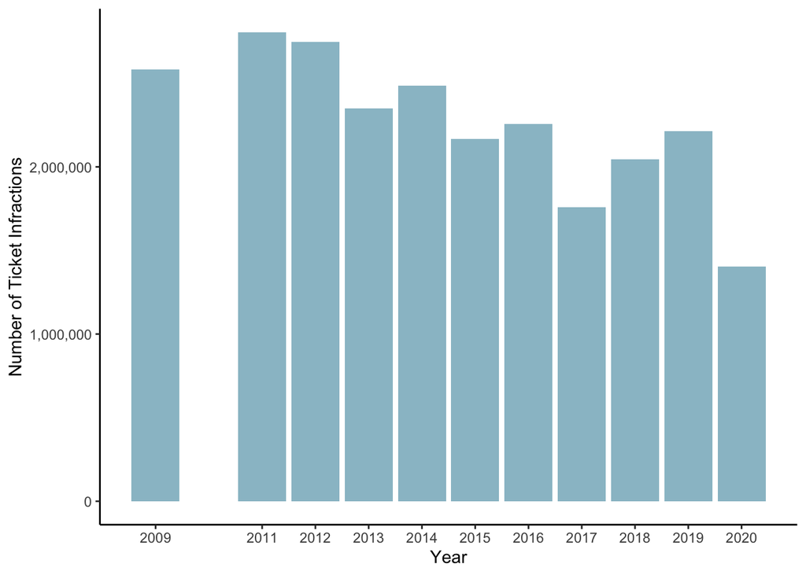

Distribution of parking ticket infractions in Toronto, ON from 2009 and 2011 to 2020 by year.

```r
#Create frequency data frame of years from park data frame
year_freq <- plyr::count(park, 'year')

#Plot the frequency of infractions by year as a bar plot
ggplot(year_freq, aes(x=year, y=freq )) +
  geom_bar(stat="identity", fill="lightblue3") +
  theme_classic() +
  xlab("Year") + ylab("Number of Ticket Infractions") +
  scale_y_continuous(labels = comma) +
  scale_x_continuous(labels = as.character(year_freq$year), breaks = year_freq$year)
```

To begin, this chart clearly shows that the data from 2010 is missing. It also shows a slight downward trend in terms of the number of infractions. The peak is in 2011 while the lowest number of infractions is in 2020. The year 2020 may be an outlier in the overall data, however, as COVID-19 may have decreased the number of cars parking in Toronto and as a result decreased the number of infractions for that year.

### 3.3.1.a.ii Distribution of infractions by month

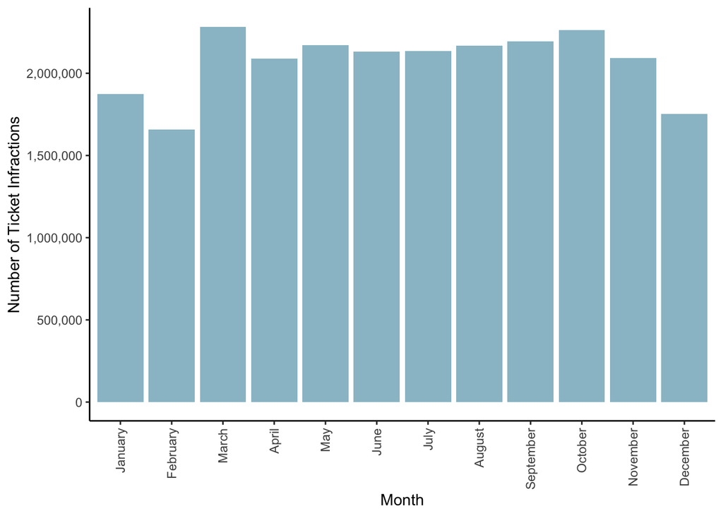

Distribution of parking ticket infractions in Toronto, ON from 2009 and 2011 to 2020 by month.

```r
#Plot the frequency of infractions by month as a bar plot
ggplot(month_freq, aes(x=month, y=freq )) +
  geom_bar(stat="identity", fill="lightblue3") +
  theme_classic() +
  xlab("Month") + ylab("Number of Ticket Infractions") +
  scale_y_continuous(labels = comma) +
  theme(axis.text.x = element_text(angle = 90, vjust = 0.5, hjust=1))
```

The chart above confirms the results previously discussed, that the winter months have less infractions in general. This visual representation, however, shows that the difference is not as extreme.

### 3.3.1.b Distribution of top 20 infractions by fines

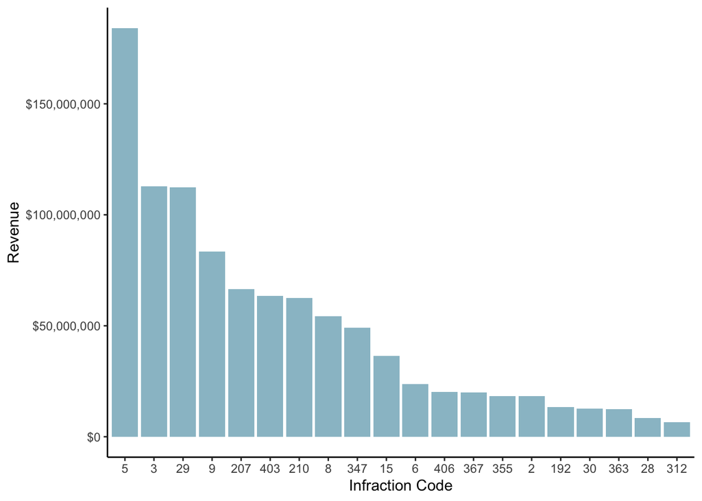

Distribution of the top 20 parking ticket infractions in Toronto, ON from 2009 and 2011 to 2020 by fines.

```r
#Plot the top 20 infractions by revenue
ggplot(top_20_rev, aes(x=reorder(factor(infraction_code), -rev), y=rev)) +
  geom_col(fill="lightblue3") +
  theme_classic() +
  xlab("Infraction Code") + ylab("Revenue") +
  scale_y_continuous(labels = dollar_format())
```

The chart above shows the top 20 parking ticket infractions by fine in decreasing order. The first infraction, code 5, has a much higher revenue in comparison to the others. In fact, this infraction alone accounts for 16.6% of revenue from the time period of this study. With 437 infraction codes, this is well above the equal share that each infraction would contribute to the revenue.

### 3.3.2.a Geographic distribution (location) of top 20 infractions (count)

### 3.3.2.b Geographic distribution by ward for top 20 infractions (count)

### 3.3.2.c Geographic distribution by ward for top 20 infractions (revenue)

### 3.3.2.d Any relevant observations in relation to socio demographic profiles